# 12_PredictionIntervals_Transformations

Author

Prof. Juan Garbayo

# References

NOTE: this notebook adapts reference 1 for the classes.

1. Hyndman, R.J., & Athanasopoulos, G., 2021. *Forecasting: principles and practice*. 3rd edition. Sections [5.5](https://otexts.com/fpp3/prediction-intervals.html) and [5.6](https://otexts.com/fpp3/ftransformations.html).
2. Fable package documentation
- https://fable.tidyverts.org/index.html
- https://fable.tidyverts.org/articles/fable.html
- https://fable.tidyverts.org/articles/transformations.html
- https://robjhyndman.com/hyndsight/backtransforming/
- https://robjhyndman.com/hyndsight/forecasting-within-limits/
3. [Forecast estimation, evaluation and transformation](https://robjhyndman.com/hyndsight/forecastmse/)

# Packages

```r
library(fpp3)
library(patchwork) # to place two plots side by side with p1 + p2

# Print 5 significant digits in tables, so 511.05762 shows as 511.06 rather than 511.
options(pillar.sigfig = 5)
```

# Reminder: point forecasts and forecast distributions (Session 8)

**$y_t$**: the random variable to be forecast. The subscript $t$ indicates the observation at time $t$.

**Prediction interval, or interval forecast**: a range of values within which we expect $y_t$ to lie with a given probability.

Let us see an example: the trend of quarterly arrivals to Australia from Japan, New Zealand, the UK and the US, taken from an STL decomposition, so that the seasonality and the noise are removed.

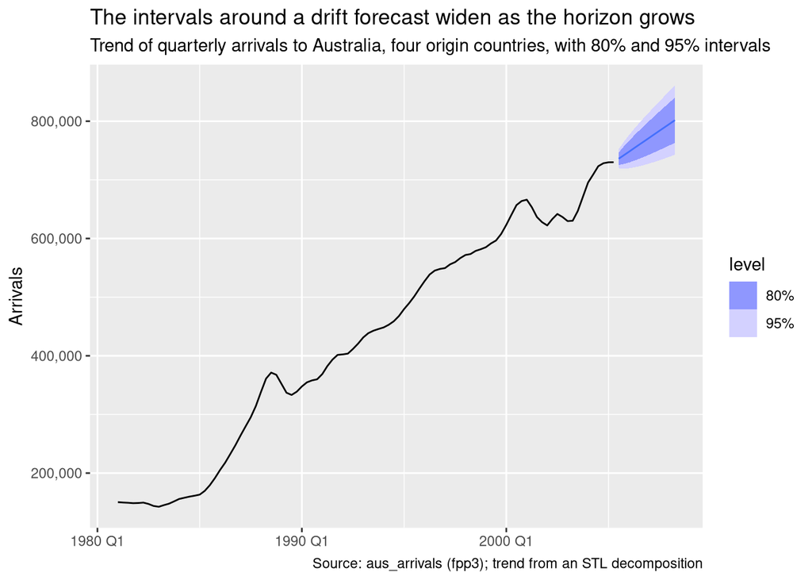

Let us now focus only on the forecast region. The figure below shows the forecast with its 80% and 95% prediction intervals at the top, and the forecast distribution at each quarter below. There is one distribution per quarter, because the data is quarterly.

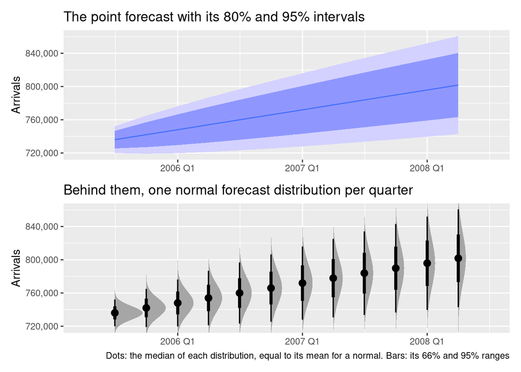

Recall from the session on benchmark methods and fitted values (Session 8) that the **point forecast is the mean of the forecast distribution.**

# Forecast distributions

Most time series models assume that the distribution of possible future values is normal: they produce **normally distributed forecasts**.

## Prediction intervals

- An interval within which we expect $y_t$ to lie with a specified probability.
- Assuming a normal forecast distribution, a two-sided prediction interval for the $h$-step forecast is:

$$\hat{y}_{T+h|T} \pm c \hat\sigma_h,$$

where:

- $\hat\sigma_h$ is an estimate of the standard deviation of the $h$-step forecast distribution.
- the multiplier $c$ depends on the **coverage probability** and is equal to the corresponding quantile of the standard normal distribution $N(0,1)$. Usually we will compute 80% and 95% intervals, although another coverage may be used.

The multiplier $c$ for the usual coverages, with $\alpha$ the probability left outside the interval. The interval leaves $\alpha/2$ in each tail, so $c$ is the percentile that leaves $\alpha/2$ above it: for 95% coverage, the 97.5th percentile, not the 95th.

Multiplier c for each coverage: the percentile of the standard normal that leaves alpha/2 in the upper tail

| Coverage | alpha | Percentile | c |
| --- | --- | --- | --- |
| 50% | 0.50 | 75th | 0.67 |
| 55% | 0.45 | 77.5th | 0.76 |
| 60% | 0.40 | 80th | 0.84 |
| 65% | 0.35 | 82.5th | 0.93 |
| 70% | 0.30 | 85th | 1.04 |
| 75% | 0.25 | 87.5th | 1.15 |
| 80% | 0.20 | 90th | 1.28 |
| 85% | 0.15 | 92.5th | 1.44 |
| 90% | 0.10 | 95th | 1.64 |
| 95% | 0.05 | 97.5th | 1.96 |
| 96% | 0.04 | 98th | 2.05 |
| 97% | 0.03 | 98.5th | 2.17 |
| 98% | 0.02 | 99th | 2.33 |
| 99% | 0.01 | 99.5th | 2.58 |

### Intervals for one-step forecasts

When forecasting **one step ahead** ($h=1$), the standard deviation of the forecast distribution can be estimated with the standard deviation of the residuals. Residuals are, after all, the errors of one-step-ahead forecasts on the training data, so they estimate $\sigma_1$, the standard deviation for $h=1$.

$$\hat\sigma_1 = \sqrt{\frac{1}{T-K}\sum_{t=1}^T e_t^2}$$

- $e_t = y_t - \hat{y}_{t|t-1}$ is the residual at time $t$: the observation minus its fitted value, as defined with the benchmark methods and fitted values (Session 8). Each fitted value is a one-step forecast, so the sum runs over every one-step miss in the training data, one residual per time point.
- $T$ is the number of residuals (after removing NAs).
- $K$ is the number of parameters estimated by the model.

### Intervals for multi-step forecasts

Prediction intervals usually widen as the forecast horizon grows. The further ahead we forecast, the more uncertain the forecast, and the wider the interval.

#### Explicit formulas for the multi-step forecast standard deviation

For some methods, the benchmark methods among them, the multi-step forecast standard deviation has an explicit formula. Deriving these formulas is not part of this course, and not every method has such a simple formula. The four benchmark methods:

| Benchmark method | h-step forecast standard deviation |
| --- | --- |
| Mean | $\hat{\sigma}_h=\hat{\sigma}\sqrt{1+1/T}$ |
| Naïve | $\hat{\sigma}_h=\hat{\sigma}\sqrt{h}$ |
| Seasonal naïve | $\hat{\sigma}_h=\hat{\sigma}\sqrt{k+1}$ |
| Drift | $\hat{\sigma}_h=\hat{\sigma}\sqrt{h(1+h/T)}$ |

- $T$ is the number of residuals (after removing NAs).
- $h$ is the forecast horizon.
- $\hat\sigma$ is the standard deviation of the residuals, the one-step estimate above.
- $k$ is the integer part of $(h-1)/m$, where $m$ is the seasonal period.
  - in other words, $k$ is the number of complete seasonal periods in the forecast prior to time $T+h$

The mean method is the exception: its formula has no $h$ in it, so its interval has the same width at every horizon, slightly wider than the one-step $\hat\sigma$.

For other models, the formulas become more complex.

#### A more general approach: bootstrapped residuals

The prediction intervals returned by the `fable` package can be trusted when the residuals pass the four checks of residual diagnostics (Session 9). Each failure does something different to the interval:

1. **No autocorrelation.** If it fails, the model has left predictable structure behind, and the interval understates how wrong the forecast will be. The fix is a richer model, such as the exponential smoothing of Sessions 15 to 19.
2. **Zero mean.** If it fails, the forecasts are biased and the interval is centered in the wrong place. Adding the mean of the residuals to every forecast fixes both.
3. **Constant variance.** If it fails, a single $\hat\sigma$ is too wide in calm stretches of the series and too narrow in volatile ones. Transforming the series with Box–Cox (Session 11) and refitting is the usual fix.
4. **Normality.** If it fails, the multiplier $c$ from the normal table is wrong, and a 95% interval no longer covers 95%.

When normality (property 4) is not a reasonable assumption, we may resort to [**bootstrapping**](https://otexts.com/fpp3/prediction-intervals.html#prediction-intervals-from-bootstrapped-residuals). It simulates many possible futures by adding residuals drawn at random from the model’s own past residuals, and reads the interval off the percentiles of the simulated values. This assumes **uncorrelated residuals with constant variance**, but not normal ones. In `fable` it is one argument, `forecast(h = ..., bootstrap = TRUE)`. Bootstrapping is not examined in this course, but you may use it.

The Google example below is a case in point: residual diagnostics (Session 9) found that the naive model’s residuals for Google 2015 are not normal, because a few huge jumps inflate $\hat\sigma$.

### Computing prediction intervals with the fable package

Let us go through a practical example of how to handle the prediction intervals that `fable` returns.

```r
google_stock <- gafa_stock |>
  filter(Symbol == "GOOG", year(Date) >= 2015) |>

  # Create regularly spaced time index `day`
  # since trading days are not evenly distributed.
  mutate(day = row_number()) |>
  update_tsibble(index = day, regular = TRUE)

google_2015 <- google_stock |> filter(year(Date) == 2015) |>
                  select(Symbol, Date, day, Close)

head(google_2015)
```

```
# A tsibble: 6 x 4 [1]
# Key:       Symbol [1]
  Symbol Date         day  Close
  <chr>  <date>     <int>  <dbl>
1 GOOG   2015-01-02     1 521.94
2 GOOG   2015-01-05     2 511.06
3 GOOG   2015-01-06     3 499.21
4 GOOG   2015-01-07     4 498.36
5 GOOG   2015-01-08     5 499.93
6 GOOG   2015-01-09     6 493.45
```

Keep the first two closing prices in mind: 521.94 on day 1 and 511.06 on day 2. The naive model’s fitted value for day 2 is day 1’s close, so its first residual is $511.06 - 521.94 = -10.88$. We meet it again when we compute $\hat\sigma$ by hand.

#### `hilo()` computes the prediction intervals

The function `hilo()` computes the prediction intervals from the forecast distributions. Without arguments, it computes the `80%` and `95%` intervals.

```r
horiz <- 5

fit <- google_2015 |>
        model(NAIVE(Close))

fc <- fit |>
        forecast(h = horiz)

fc_hilo <- fc |> hilo()

# Show the columns that matter here: the horizon, the point forecast and the two intervals
fc_hilo |> select(day, .mean, `80%`, `95%`)
```

```
# A tsibble: 5 x 4 [1]
    day  .mean                  `80%`                  `95%`
  <dbl>  <dbl>                 <hilo>                 <hilo>
1   253 758.88 [744.5400, 773.2200]80 [736.9488, 780.8112]95
2   254 758.88 [738.6001, 779.1599]80 [727.8646, 789.8954]95
3   255 758.88 [734.0423, 783.7177]80 [720.8941, 796.8659]95
4   256 758.88 [730.1999, 787.5601]80 [715.0176, 802.7424]95
5   257 758.88 [726.8147, 790.9453]80 [709.8404, 807.9196]95
```

`fc_hilo` has seven columns: the keys `Symbol` and `.model`, the index `day`, the forecast distribution `Close`, its mean `.mean`, and the two intervals. Printed whole, it is wider than the console, so R shows the columns that fit and lists the rest underneath the table (“2 more variables: …”). Selecting the columns you need avoids that.

#### Inspecting the prediction intervals

There are two ways to extract the limits of the intervals computed by `hilo()`:

1. (Not recommended) extract one element of the vector of intervals:

```r
# Vector of 80% prediction intervals
pints_80 <- fc_hilo |> pull(`80%`)
pints_80[1]
```

```
<hilo[1]>
[1] [744.54, 773.22]80
```

Then we can access the components `lower`, `upper` and `level` using the `$` operator:

```r
pints_80[1]$lower # Lower bound of the prediction interval
```

```
[1] 744.54
```

```r
pints_80[1]$upper # Upper bound of the prediction interval
```

```
[1] 773.22
```

```r
pints_80[1]$level # Coverage level
```

```
[1] 80
```

2. Use `unpack_hilo()` to create new columns with the limits of the intervals: `*_lower` and `*_upper` for each interval unpacked. Remember that the column `.mean` of the forecast table is the mean of the forecast distribution.

```r
fc_hilo <- fc_hilo |>
  unpack_hilo(c(`80%`, `95%`))

fc_hilo |>
  select(day, .mean, `80%_lower`, `80%_upper`, `95%_lower`, `95%_upper`)
```

```
# A tsibble: 5 x 6 [1]
    day  .mean `80%_lower` `80%_upper` `95%_lower` `95%_upper`
  <dbl>  <dbl>       <dbl>       <dbl>       <dbl>       <dbl>
1   253 758.88      744.54      773.22      736.95      780.81
2   254 758.88      738.60      779.16      727.86      789.90
3   255 758.88      734.04      783.72      720.89      796.87
4   256 758.88      730.20      787.56      715.02      802.74
5   257 758.88      726.81      790.95      709.84      807.92
```

#### Check: the mean of the forecast distribution (the point forecast) is the center of the prediction interval

When the forecast distribution is symmetric, as a normal distribution is, its mean and its median coincide, and every interval is centered on them. The point forecast is the mean of the forecast distribution (column `.mean` of the fable), so it should sit exactly at the midpoint of each interval:

```r
# Compute the midpoints of the 95% prediction intervals
midpoints <- fc_hilo |>
  mutate(midpoints = (`95%_lower` + `95%_upper`) / 2) |>
  pull(midpoints)

# Check that the column .mean is the midpoint of the intervals
all.equal(midpoints, fc_hilo$.mean)
```

```
[1] TRUE
```

#### Plotting prediction intervals

When plotting forecasts, `autoplot()` draws the 80% and 95% prediction intervals by default. Set `level = NULL` to leave them out.

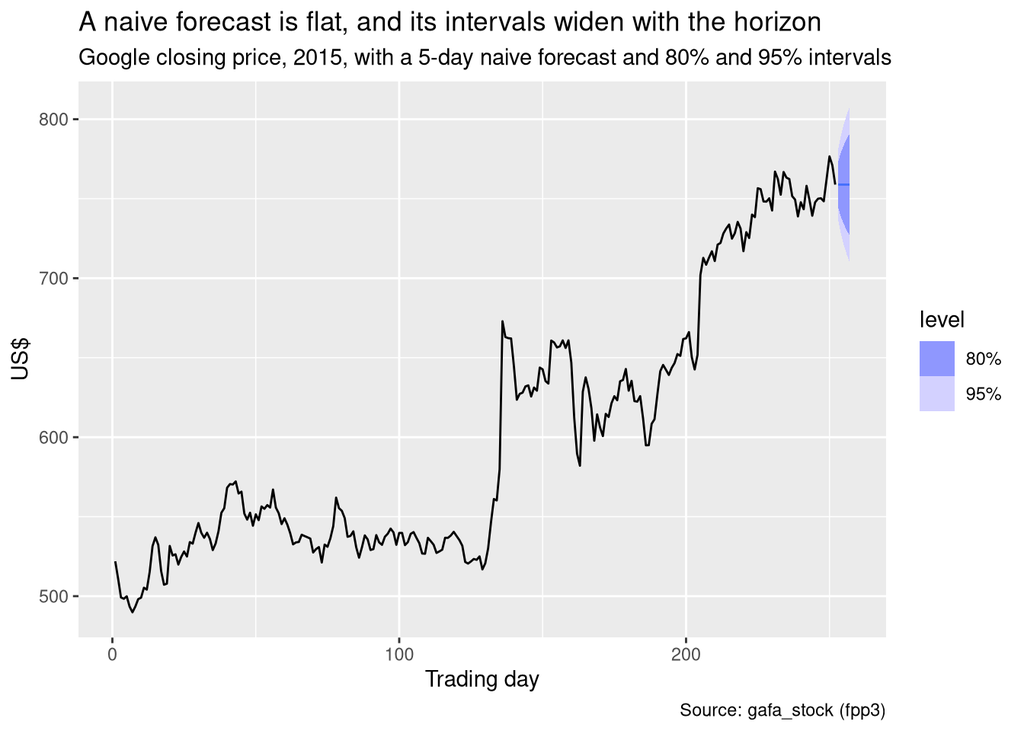

```r
fc |>
  autoplot(google_2015) +
  labs(title = "A naive forecast is flat, and its intervals widen with the horizon",
       subtitle = "Google closing price, 2015, with a 5-day naive forecast and 80% and 95% intervals",
       x = "Trading day", y = "US$",
       caption = "Source: gafa_stock (fpp3)")
```

Again, let us zoom in on the forecast region. The figure below shows the point forecast (blue line), the 80% and 95% prediction intervals (shaded blue regions), and the forecast distributions underneath. The model generates normal forecast distributions.

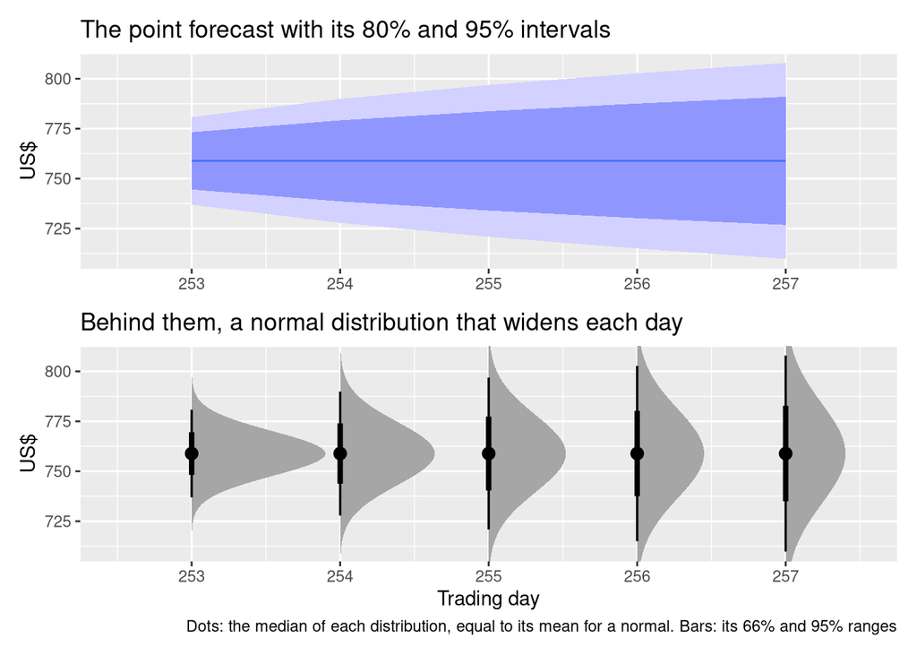

#### Extracting the parameters of the forecast distributions

By now you will have noticed that a forecast table has a column of type `<dist>`. It holds the forecast distribution at each horizon, and it always carries the name of the response variable, in this case `Close`.

```r
fc |> select(day, Close)
```

```
# A fable: 5 x 2 [1]
    day       Close
  <dbl>      <dist>
1   253 N(759, 125)
2   254 N(759, 250)
3   255 N(759, 376)
4   256 N(759, 501)
5   257 N(759, 626)
```

The function `parameters()` from the `distributional` package returns the parameters of each distribution. The package is installed with `fpp3`; here we call the function with `::` instead of loading the package.

```r
fc |> pull(Close) |> distributional::parameters()
```

```
      mu    sigma
1 758.88 11.18958
2 758.88 15.82446
3 758.88 19.38093
4 758.88 22.37917
5 758.88 25.02067
```

The column `sigma` is $\hat\sigma_h$, the standard deviation of the forecast distribution at each horizon. At $h = 1$ it is 11.19, the standard deviation of the residuals, computed by hand in the next section. At $h = 2$ it is 15.82, which is $11.19 \times \sqrt{2}$: the naive formula $\hat\sigma_h = \hat\sigma\sqrt{h}$ from the table above.

#### Check: manual computation of a prediction interval vs `hilo()`

As an example, let us compute by hand the 95% prediction interval for the 1-step forecast of the example above (Google stock prices, 2015).

We noted before that, **for a 1-step-ahead interval, the standard deviation of the forecast distribution can be estimated from the standard deviation of the residuals**:

$$\hat{\sigma} = \sqrt{\frac{1}{T-K}\sum_{t=1}^T e_t^2}$$

- $e_t = y_t - \hat{y}_{t|t-1}$ is the residual at time $t$: the observation minus its fitted value, as defined with the benchmark methods and fitted values (Session 8). Each fitted value is a one-step forecast, so the sum runs over every one-step miss in the training data, one residual per time point.
- $T$ is the number of residuals (after removing NAs).
- $K$ is the number of parameters estimated by the model.

For Google 2015 and the naive model, there are 252 trading days and 251 residuals: the first day has no previous observation, so no fitted value. The first rows show each residual as the observation minus its fitted value, the previous close:

```r
fit |> augment() |> as_tibble() |> select(day, Close, .fitted, .innov) |> head(3)
```

```
# A tibble: 3 × 4
    day  Close .fitted  .innov
  <int>  <dbl>   <dbl>   <dbl>
1     1 521.94   NA     NA
2     2 511.06  521.94 -10.880
3     3 499.21  511.06 -11.845
```

Using the formula above:

```r
# Extract the residuals
res <- fit |> augment() |> pull(.innov)
# Remove missing values before counting them
res <- res[!is.na(res)]

# T and K in the formula. R already uses T as a shorthand for TRUE,
# so the code calls them n_res and K.
n_res <- length(res)  # number of residuals
K <- nrow(tidy(fit))  # number of estimated parameters: 0 for the naive model

sum(res^2)   # numerator: the sum of the squared residuals
```

```
[1] 31426.9
```

```r
n_res - K    # denominator: T - K
```

```
[1] 251
```

```r
sigma_res <- sqrt(sum(res^2) / (n_res - K))
sigma_res
```

```
[1] 11.18958
```

```r
# Check that it matches the standard deviation of the forecast distribution
all.equal(sigma_res, distributional::parameters(fc$Close[1])$sigma)
```

```
[1] TRUE
```

So $\hat\sigma = \sqrt{31{,}426.9 / 251} = \sqrt{125.21} = 11.19$, the `sigma` that `parameters()` reported at $h = 1$.

With this we can compute the prediction interval around the point forecast (the mean of the forecast distribution), applying the formula:

$$\hat{y}_{T+h|T} \pm c \hat\sigma_h,$$

where:

- $\hat\sigma_h$ is an estimate of the standard deviation of the $h$-step forecast distribution.
- the multiplier $c$ depends on the **coverage probability** and is equal to the corresponding quantile of the standard normal distribution. Usually we will compute 80% and 95% intervals, although another coverage may be used.

For a 95% prediction interval we need the 97.5th percentile of the standard normal distribution, its $1-0.05/2 = 0.975$ quantile (see the table of multipliers in Prediction intervals).

```r
# Point forecast, which in this case is the mean of the forecast distribution
y_hat <- fc$.mean[1]

# Quantile of the standard normal distribution
alpha <- 0.05 # 95% prediction interval
quant <- qnorm(1 - alpha / 2)

# Prediction interval computed by hand
PI <- c(y_hat - quant * sigma_res, y_hat + quant * sigma_res)

# Prediction interval computed by fable
PI_hilo <- c(fc_hilo$`95%_lower`[1], fc_hilo$`95%_upper`[1])

# The interval computed by hand
PI
```

```
[1] 736.9488 780.8112
```

```r
# Check that it matches the one returned by fable
all.equal(PI, PI_hilo)
```

```
[1] TRUE
```

To compute intervals beyond a horizon of 1, we need an estimate of the standard deviation of the forecast distribution at that horizon. As noted earlier, explicit formulas exist for the four benchmark methods: mean, naïve, seasonal naïve and drift. More complex methods have no such simple formula, but each has its own way of computing it. As long as the residuals pass the four checks listed above, the intervals `fable` returns can be trusted.

Prediction intervals can also be computed from bootstrapped residuals, as noted earlier. That assumes uncorrelated residuals with constant variance, but not normal ones.

# Forecasting and transformations

When the data has been transformed:

1. The forecasts are produced on the transformed scale.
2. To obtain forecasts on the original scale, we need to **back-transform** them.

The Box–Cox transformation has an explicit inverse, so this could be done by hand. But `fable`, like any good forecasting software, does it for you:

$$\text{Box–Cox back-transformation: } \ \ \ \ y_{t} =
\begin{cases}
\exp(w_{t}) & \text{if $\lambda=0$};\\
\text{sign}(\lambda w_t+1)|\lambda w_t+1|^{1/\lambda} & \text{otherwise}.
\end{cases}$$

The `fable` package **performs the back-transformation automatically if the transformation is part of the model definition**.

## Prediction intervals and transformations

The forecast distribution is also transformed when the transformation is reversed. Consider the figure below, drawn for a log transformation:

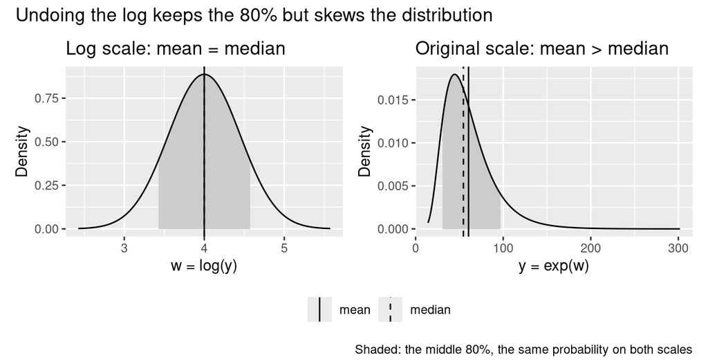

On the transformed scale ($w_t$), the model assumes normal errors, so the forecast distribution is symmetric there. But once it is brought back to the original scale, to give forecasts of $y_t$, it is no longer symmetric. Because the Box–Cox transformation is continuous and strictly monotonic, the quantiles are preserved: the probability coverage of any interval on the transformed scale survives the back-transformation to the original scale.

- The end points of the prediction intervals on the transformed scale are back-transformed to give a prediction interval on the original scale. This preserves the **probability coverage** of the prediction interval, but the interval is no longer symmetric around the point forecast.
- The back-transformed point forecast is in general not the mean of the forecast distribution on the original scale. If the forecast distribution on the transformed scale is symmetric, the back-transformed point forecast is its **median**.
- The difference between the back-transformed forecast and the mean is called the **bias**. When using the mean rather than the median, we say the point forecasts have been **bias-adjusted**.
  - Using the median may be acceptable in many forecasting situations.
  - Some situations need a property of the mean that the median lacks. For example, adding up sales forecasts for several regions to forecast the whole country requires means, because **medians do not add up**.
  - The larger the forecast variance, the larger the difference between the mean and the median. This follows from the formulas below, which approximate the **back-transformed mean on the original scale**. In them, $\hat{w}_{T+h|T}$ is the $h$-step forecast mean and $\sigma_h^2$ the $h$-step forecast variance, **both on the transformed scale**:

$$\hat{y}_{T+h|T} =
\begin{cases}
\exp(\hat{w}_{T+h|T})\left[1 + \frac{\sigma_h^2}{2}\right] & \text{if $\lambda=0$;}\\
(\lambda \hat{w}_{T+h|T}+1)^{1/\lambda}\left[1 + \frac{\sigma_h^2(1-\lambda)}{2(\lambda \hat{w}_{T+h|T}+1)^{2}}\right] & \text{otherwise.}
\end{cases}$$

The back-transformation that `fable` performs automatically does two things:

1. Forecasts come back on the original scale rather than the transformed one, provided the transformation was declared in the model definition.
2. The point forecast in the column `.mean` is the mean of the back-transformed distribution (bias-adjusted), not the back-transformed median.

The following example illustrates three important points:

1. The log transformation is applied in the model definition rather than before it, so that `fable` can back-transform automatically. That is, so that the package **knows** there is a transformation involved.
2. `autoplot()` can draw both the mean and the median point forecasts of the back-transformed distributions, with the argument `point_forecast = lst(mean, median)`.
3. Most importantly, the back-transformed forecast distribution is **not symmetric**. The mean and the median differ, and neither sits at the midpoint of the interval.

```r
# Create a new column to hold the transformed variable
prices <- prices |>
  mutate(log_eggs = log(eggs))
```

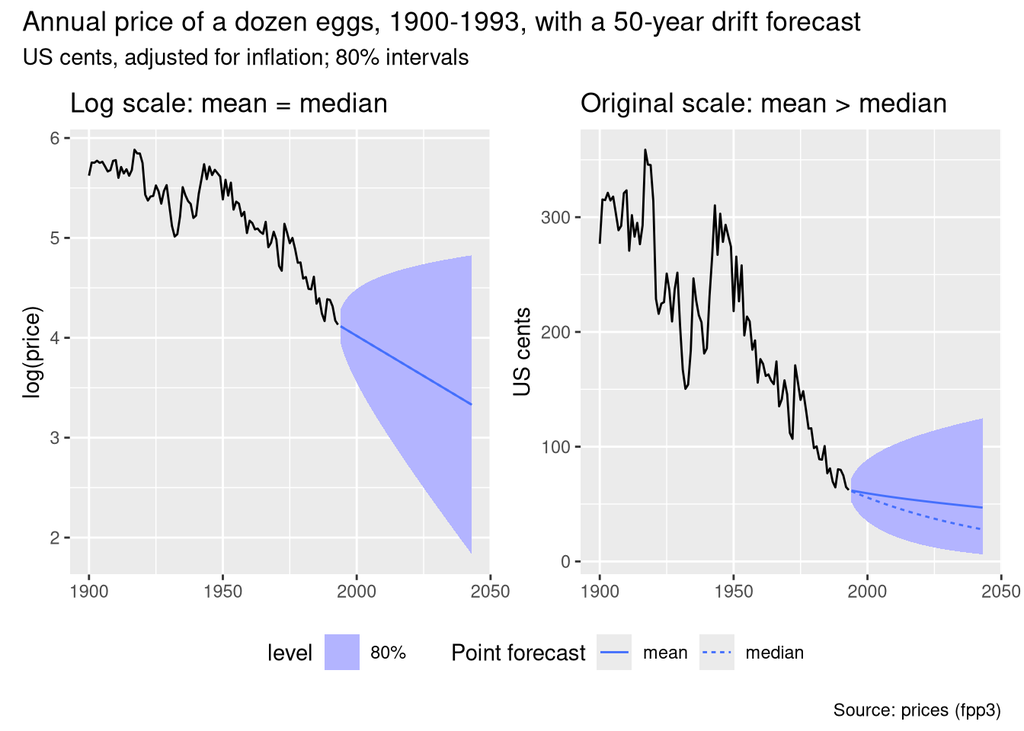

```r
# forecast horizon
horiz <- 50

# Model 1: fitted to the variable already transformed
fit1 <- prices |>
  filter(!is.na(eggs)) |>
  model(drift = RW(log_eggs ~ drift()))

# fc1: forecasts generated with model 1
fc1 <- fit1 |>
  forecast(h = horiz)

# Model 2: fitted to the original variable, with the transformation in the model definition
fit2 <- prices |>
  filter(!is.na(eggs)) |> # keep the years with an egg price
  model(RW(log(eggs) ~ drift()))

# fc2: forecasts generated with model 2
fc2 <- fit2 |>
  forecast(h = horiz)

# One figure per model, each with the mean and the median point forecasts
fig1 <- fc1 |>
  autoplot(prices |> filter(!is.na(eggs)),
           level = 80, point_forecast = lst(mean, median)) +
  labs(title = "Log scale: mean = median",
       x = NULL, y = "log(price)")

fig2 <- fc2 |>
  autoplot(prices |> filter(!is.na(eggs)),
           level = 80, point_forecast = lst(mean, median)) +
  labs(title = "Original scale: mean > median",
       x = NULL, y = "US cents")

(fig1 + fig2) +
  plot_layout(guides = "collect") + # one shared legend for the two plots
  plot_annotation(
    title = "Annual price of a dozen eggs, 1900-1993, with a 50-year drift forecast",
    subtitle = "US cents, adjusted for inflation; 80% intervals",
    caption = "Source: prices (fpp3)"
  ) &
  theme(legend.position = "bottom")
```

In the above graph:

- The left side shows the series and the forecasts on the transformed scale. The mean and the median coincide: the forecast distribution on the transformed scale is symmetric.
- The right side shows the series and the forecasts on the original scale, once everything has been back-transformed. The legend tells the mean and the median apart; the further into the future, the further apart they are. These forecast distributions are clearly not symmetric.

The figure below focuses on the forecast region and shows the forecast distributions on the transformed scale (left) and on the original scale (right), to make the loss of symmetry plain.

- Remember that the coverage of a prediction interval computed on the transformed scale is preserved when back-transforming, because the transformation is strictly monotonic. The difference is that, on the original scale, the interval is no longer symmetric around the mean of the forecast distribution.

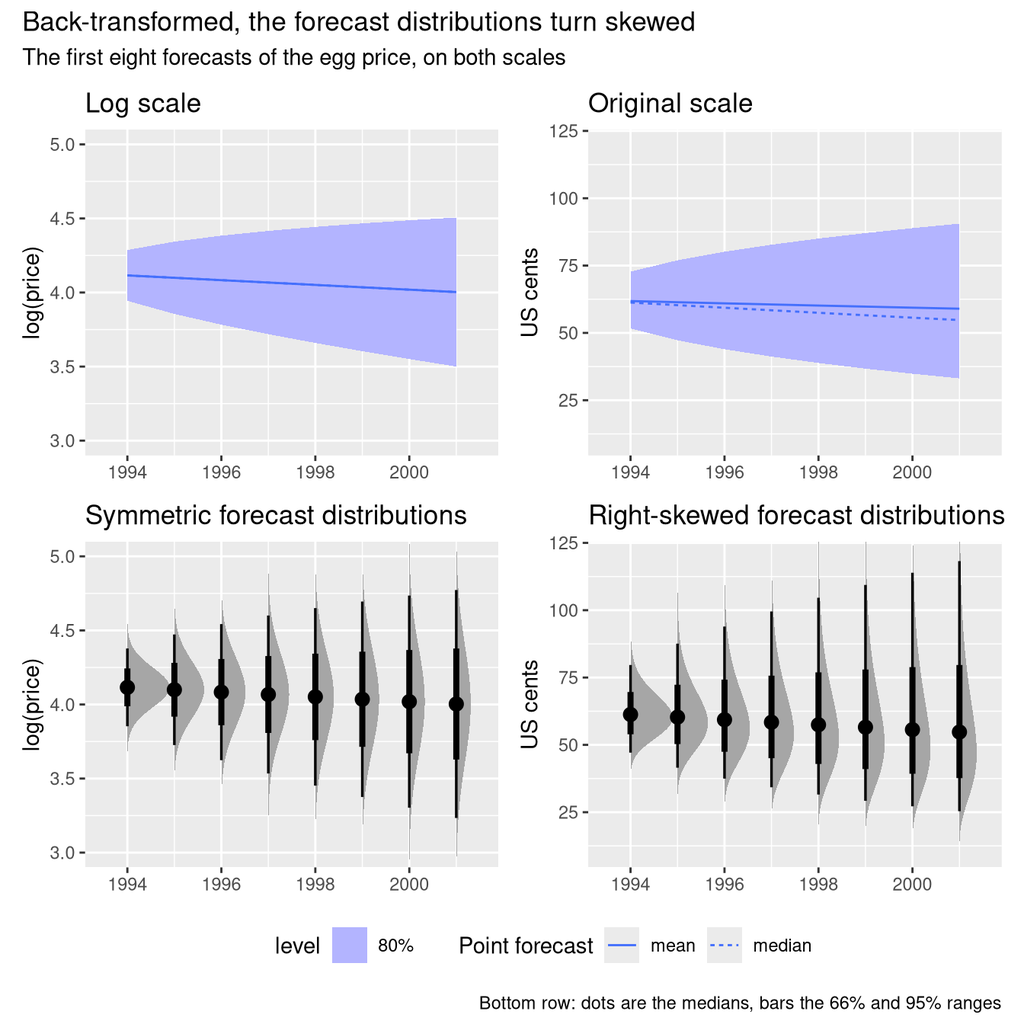

#### Understanding the forecasts returned when using transformations

Remember that, in the previous example, we fitted two models:

- **Model 1**: fitted to the transformed variable `log_eggs = log(eggs)`

```r
# Model 1: fitted to the variable already transformed
fit1 <- prices |>
  filter(!is.na(eggs)) |>
  model(drift = RW(log_eggs ~ drift()))
```

- **Model 2**: fitted to the original variable, with the transformation declared in the model definition:

```r
# Model 2: fitted to the original variable, with the transformation in the model definition
fit2 <- prices |>
  filter(!is.na(eggs)) |> # keep the years with an egg price
  model(RW(log(eggs) ~ drift()))
```

With those models we generated two forecast objects:

- `fc1`, from model 1. It returns forecasts on the transformed scale, because the model works on the transformed variable directly.

```r
head(fc1, 4) |> select(year, log_eggs, .mean)
```

```
# A fable: 4 x 3 [1Y]
   year      log_eggs  .mean
  <dbl>        <dist>  <dbl>
1  1994 N(4.1, 0.018) 4.1154
2  1995 N(4.1, 0.036) 4.0994
3  1996 N(4.1, 0.055) 4.0834
4  1997 N(4.1, 0.074) 4.0673
```

- `fc2`, from model 2. `fable` knows that model 2 has a transformation, so it back-transforms to the original scale and returns **bias-adjusted forecasts**: the column `.mean` is the mean of the back-transformed forecast distribution.

```r
head(fc2, 4) |> select(year, eggs, .mean)
```

```
# A fable: 4 x 3 [1Y]
   year             eggs  .mean
  <dbl>           <dist>  <dbl>
1  1994 t(N(4.1, 0.018)) 61.828
2  1995 t(N(4.1, 0.036)) 61.397
3  1996 t(N(4.1, 0.055)) 60.974
4  1997 t(N(4.1, 0.074)) 60.561
```

#### Some checks on the forecasts and forecast distributions

##### Check 1: back-transforming the bounds of the intervals on the transformed scale gives the intervals on the original scale

```r
# Lower and upper bounds of the 80% and 95% prediction intervals
# on the transformed scale
fc1_intervals <-
  fc1 |>
    hilo() |>
    unpack_hilo(c(`80%`, `95%`))

# Lower and upper bounds of the 80% and 95% prediction intervals
# on the original scale
fc2_intervals <-
  fc2 |>
    hilo() |>
    unpack_hilo(c(`80%`, `95%`))

# Back-transform 95% lower bound
fc2_95lower_manual <- exp(fc1_intervals$`95%_lower`)
fc2_95lower_fable <- fc2_intervals$`95%_lower`

# Back-transform 95% upper bound
fc2_95upper_manual <- exp(fc1_intervals$`95%_upper`)
fc2_95upper_fable <- fc2_intervals$`95%_upper`

# CHECK
all.equal(fc2_95lower_manual, fc2_95lower_fable)
```

```
[1] TRUE
```

```r
all.equal(fc2_95upper_manual, fc2_95upper_fable)
```

```
[1] TRUE
```

##### Check 2: the mean on the transformed scale back-transforms to the median on the original scale

```r
# Back-transform the forecasts on the transformed scale (their mean)
fc1_backtransf <- exp(fc1$.mean)

# Medians of the forecast distributions of fc2
# (fc2$eggs is the column of forecast distributions)
fc2_median <- median(fc2$eggs)

# CHECK
all.equal(fc1_backtransf, fc2_median)
```

```
[1] TRUE
```

##### Check 3: `fable` bias-adjusts the forecasts on the original scale, returning the mean of the back-transformed distribution

```r
# Compute the means of the distributions of fc2
fc2_mean_manual <- mean(fc2$eggs)

# Point forecasts (bias-adjusted)
fc2_point <- fc2$.mean

# CHECK
all.equal(fc2_mean_manual, fc2_point)
```

```
[1] TRUE
```

So `fable` returns bias-adjusted forecasts (the mean) automatically. If we want the median instead, we take the median of each forecast distribution, held in the column `eggs` of `fc2`. The following returns the median at every forecast horizon.

```r
median(fc2$eggs)
```

```
 [1] 61.27912 60.30400 59.34441 58.40008 57.47078 56.55626 55.65630 54.77066
 [9] 53.89911 53.04143 52.19740 51.36680 50.54942 49.74504 48.95347 48.17449
[17] 47.40790 46.65352 45.91113 45.18056 44.46162 43.75412 43.05787 42.37271
[25] 41.69844 41.03491 40.38194 39.73935 39.10699 38.48470 37.87230 37.26965
[33] 36.67659 36.09297 35.51863 34.95344 34.39723 33.84988 33.31124 32.78117
[41] 32.25953 31.74620 31.24103 30.74390 30.25469 29.77325 29.29948 28.83325
[49] 28.37443 27.92292
```

# Exercise 1

Use `decomposition_model()` with an STL decomposition and a log transformation to generate a 36-step forecast of the `retail_series` used in Exercise 1 of notebook `08_A`. Plot the forecasts on the original scale with both the mean and the median point forecasts.

As in `08_A`, use a drift model for the seasonally adjusted data and a seasonal naive model for the seasonal component.

```r
retail_series <- aus_retail |>
  filter(`Series ID` == "A3349767W")
```